# Climate Change

2020-09-07

**Return to [Portfolio site](https://johanna-jeffery-portfolio.netlify.app)**

# Climate Change and Temperature Anomalies

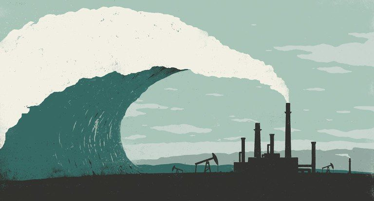

This project looks to study climate change, and draws on data from the *Combined Land-Surface Air and Sea-Surface Water Temperature Anomalies* in the Northern Hemisphere at [NASA’s Goddard Institute for Space Studies](https://data.giss.nasa.gov/gistemp). The [tabular data of temperature anomalies can be found here](https://data.giss.nasa.gov/gistemp/tabledata_v3/NH.Ts+dSST.txt)

To define temperature anomalies you need to have a reference, or base, period which NASA clearly states that it is the period between 1951-1980.

Let’s load the data:

```r
weather <- read_csv("https://data.giss.nasa.gov/gistemp/tabledata_v3/NH.Ts+dSST.csv",

# The real data in the table only starts in row 2, so we use the skip function to skip one row
           skip = 1,

# In this data set, missing data isn't coded as 'NA', but rather as ***, so we specify this here

           na = "***")

weather
```

```
## # A tibble: 140 x 19
##     Year   Jan    Feb    Mar   Apr   May   Jun   Jul   Aug   Sep   Oct   Nov
##    <dbl> <dbl>  <dbl>  <dbl> <dbl> <dbl> <dbl> <dbl> <dbl> <dbl> <dbl> <dbl>
##  1  1880 -0.54 -0.38  -0.26  -0.37 -0.11 -0.22 -0.23 -0.24 -0.26 -0.32 -0.37
##  2  1881 -0.19 -0.25   0.02  -0.02 -0.06 -0.36 -0.06 -0.03 -0.23 -0.4  -0.42
##  3  1882  0.22  0.22   0     -0.36 -0.32 -0.38 -0.37 -0.14 -0.17 -0.53 -0.32
##  4  1883 -0.59 -0.67  -0.16  -0.27 -0.32 -0.26 -0.09 -0.26 -0.33 -0.21 -0.4
##  5  1884 -0.23 -0.11  -0.65  -0.62 -0.42 -0.52 -0.48 -0.5  -0.45 -0.41 -0.48
##  6  1885 -1    -0.37  -0.21  -0.53 -0.55 -0.47 -0.39 -0.44 -0.32 -0.3  -0.28
##  7  1886 -0.68 -0.68  -0.570 -0.34 -0.34 -0.43 -0.2  -0.47 -0.34 -0.31 -0.45
##  8  1887 -1.07 -0.580 -0.36  -0.42 -0.27 -0.2  -0.23 -0.52 -0.17 -0.4  -0.19
##  9  1888 -0.53 -0.59  -0.580 -0.24 -0.16 -0.04  0.04 -0.19 -0.12  0.04 -0.03
## 10  1889 -0.31  0.35   0.07   0.15 -0.05 -0.12 -0.1  -0.16 -0.26 -0.34 -0.61
## # … with 130 more rows, and 7 more variables: Dec <dbl>, `J-D` <dbl>,
## #   `D-N` <dbl>, DJF <dbl>, MAM <dbl>, JJA <dbl>, SON <dbl>
```

For each month and year, the dataframe shows the deviation of temperature from the normal (expected). Further the dataframe is in wide format.

First let’s select the variables we need.

```r
weather2 <- weather %>% select(-`J-D`, -`D-N`, -DJF, -MAM, -JJA, -SON)
weather2
```

```
## # A tibble: 140 x 13
##     Year   Jan    Feb    Mar   Apr   May   Jun   Jul   Aug   Sep   Oct   Nov
##    <dbl> <dbl>  <dbl>  <dbl> <dbl> <dbl> <dbl> <dbl> <dbl> <dbl> <dbl> <dbl>
##  1  1880 -0.54 -0.38  -0.26  -0.37 -0.11 -0.22 -0.23 -0.24 -0.26 -0.32 -0.37
##  2  1881 -0.19 -0.25   0.02  -0.02 -0.06 -0.36 -0.06 -0.03 -0.23 -0.4  -0.42
##  3  1882  0.22  0.22   0     -0.36 -0.32 -0.38 -0.37 -0.14 -0.17 -0.53 -0.32
##  4  1883 -0.59 -0.67  -0.16  -0.27 -0.32 -0.26 -0.09 -0.26 -0.33 -0.21 -0.4
##  5  1884 -0.23 -0.11  -0.65  -0.62 -0.42 -0.52 -0.48 -0.5  -0.45 -0.41 -0.48
##  6  1885 -1    -0.37  -0.21  -0.53 -0.55 -0.47 -0.39 -0.44 -0.32 -0.3  -0.28
##  7  1886 -0.68 -0.68  -0.570 -0.34 -0.34 -0.43 -0.2  -0.47 -0.34 -0.31 -0.45
##  8  1887 -1.07 -0.580 -0.36  -0.42 -0.27 -0.2  -0.23 -0.52 -0.17 -0.4  -0.19
##  9  1888 -0.53 -0.59  -0.580 -0.24 -0.16 -0.04  0.04 -0.19 -0.12  0.04 -0.03
## 10  1889 -0.31  0.35   0.07   0.15 -0.05 -0.12 -0.1  -0.16 -0.26 -0.34 -0.61
## # … with 130 more rows, and 1 more variable: Dec <dbl>
```

```r
# The data is currently in a 'wide' format, whereas we need it in a long format

tidyweather <- weather2 %>% pivot_longer(cols=2:13, names_to="month", values_to="delta")
tidyweather
```

```
## # A tibble: 1,680 x 3
##     Year month delta
##    <dbl> <chr> <dbl>
##  1  1880 Jan   -0.54
##  2  1880 Feb   -0.38
##  3  1880 Mar   -0.26
##  4  1880 Apr   -0.37
##  5  1880 May   -0.11
##  6  1880 Jun   -0.22
##  7  1880 Jul   -0.23
##  8  1880 Aug   -0.24
##  9  1880 Sep   -0.26
## 10  1880 Oct   -0.32
## # … with 1,670 more rows
```

## Plotting Information

In order to plot the data using a time-series scatter plot, we need to create a new variable called `date` to ensure that the `delta` values plot chronologically. We can do this using the `lubridate` package.

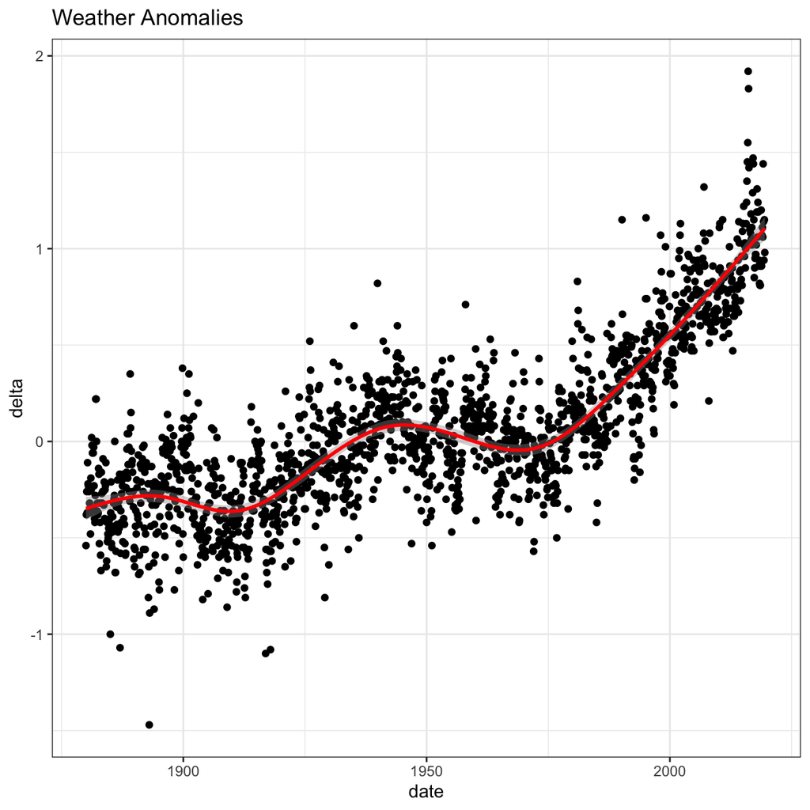

```r
tidyweather <- tidyweather %>%
  mutate(date = ymd(paste(as.character(Year), month, "1")), #lubridate used
         month = month(date, label=TRUE),
         Year = year(date))

ggplot(tidyweather, aes(x=date, y = delta))+
  geom_point()+
  geom_smooth(color="red") +
  theme_bw() +
  labs (
    title = "Weather Anomalies"
  )
```

Let’s see if the effect of rising temperatures is more pronounced in certain months.

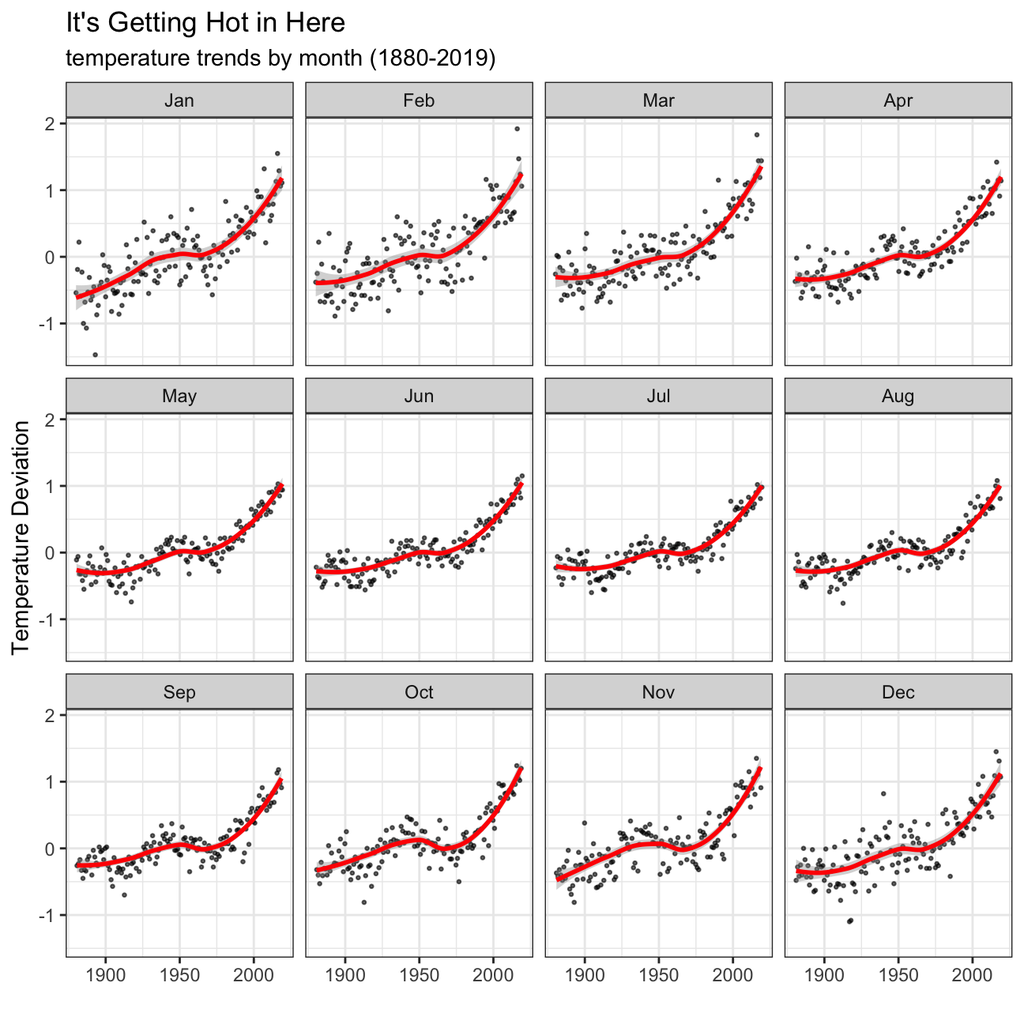

```r
ggplot(tidyweather, aes(x=date, y = delta))+
  geom_point(size=0.5, alpha=0.6)+
  geom_smooth(color="red") +
  facet_wrap(~month) +
  theme_bw() +
  labs (
    title = "It's Getting Hot in Here",
    subtitle="temperature trends by month (1880-2019)",
    y="Temperature Deviation",
    x=""
  )
```

It is sometimes useful to group data into different time periods to study historical data. For example, we often refer to decades such as 1970s, 1980s, 1990s etc. to refer to a period of time. NASA calculates a temperature anomaly, as difference form the base period of 1951-1980. The code below creates a new data frame called `comparison` that groups data in five time periods: 1881-1920, 1921-1950, 1951-1980, 1981-2010 and 2011-present.

```r
comparison <- tidyweather %>%
  filter(Year>= 1881) %>%     #remove years prior to 1881

  #create new variable 'interval', and assign values based on criteria below:

  mutate(interval = case_when(
    Year %in% c(1881:1920) ~ "1881-1920",
    Year %in% c(1921:1950) ~ "1921-1950",
    Year %in% c(1951:1980) ~ "1951-1980",
    Year %in% c(1981:2010) ~ "1981-2010",
    TRUE ~ "2011-present"
  ))

comparison
```

```
## # A tibble: 1,668 x 5
##     Year month delta date       interval
##    <dbl> <ord> <dbl> <date>     <chr>
##  1  1881 Jan   -0.19 1881-01-01 1881-1920
##  2  1881 Feb   -0.25 1881-02-01 1881-1920
##  3  1881 Mar    0.02 1881-03-01 1881-1920
##  4  1881 Apr   -0.02 1881-04-01 1881-1920
##  5  1881 May   -0.06 1881-05-01 1881-1920
##  6  1881 Jun   -0.36 1881-06-01 1881-1920
##  7  1881 Jul   -0.06 1881-07-01 1881-1920
##  8  1881 Aug   -0.03 1881-08-01 1881-1920
##  9  1881 Sep   -0.23 1881-09-01 1881-1920
## 10  1881 Oct   -0.4  1881-10-01 1881-1920
## # … with 1,658 more rows
```

Now that we have the `interval` variable, we can create a density plot to study the distribution of monthly deviations (`delta`), grouped by the different time periods we are interested in.

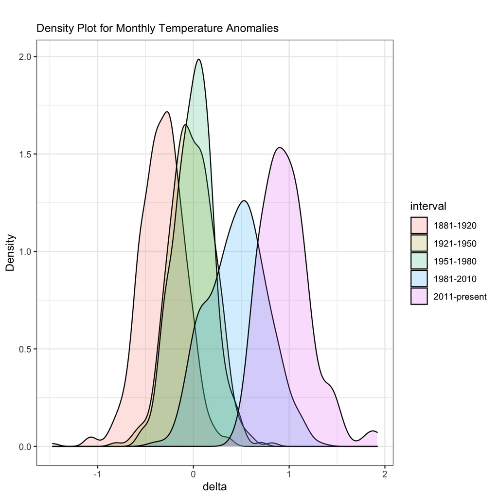

```r
ggplot(comparison, aes(x=delta, fill=interval))+

  geom_density(alpha=0.2) +   #density plot with transparency set to 20%

  theme_bw() +                #theme

  labs (
    title = "",
    subtitle = "Density Plot for Monthly Temperature Anomalies",
    y     = "Density"
  )
```

So far, we have been working with monthly anomalies. However, we might be interested in average annual anomalies. We can do this by using `group_by()` and `summarise()`, followed by a scatter plot to display the result.

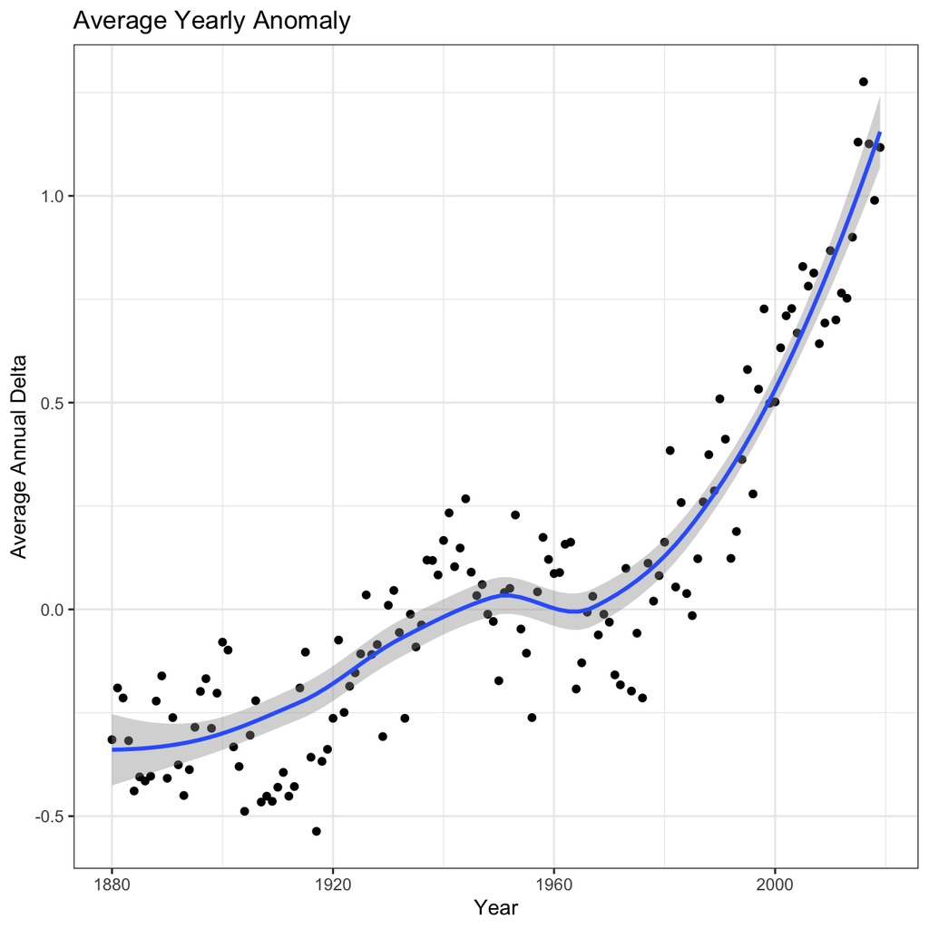

```r
#creating yearly averages
average_annual_anomaly <- tidyweather %>%
  group_by(Year) %>%   #grouping data by Year

  # creating summaries for mean delta
  # use `na.rm=TRUE` to eliminate NA (not available) values

  summarise(annual_average_delta = mean(delta, na.rm=TRUE))

#plotting the data:
ggplot(average_annual_anomaly, aes(x=Year, y= annual_average_delta))+
  geom_point()+

  #Fit the best fit line, using LOESS method
  geom_smooth() +

  #change to theme_bw() to have white background + black frame around plot
  theme_bw() +
  labs (
    title = "Average Yearly Anomaly",
    y     = "Average Annual Delta"
  )
```

## Confidence Interval for `delta`

[NASA points out on their website](https://earthobservatory.nasa.gov/world-of-change/decadaltemp.php) that a one-degree global change is significant because it takes a vast amount of heat to warm all the oceans, atmosphere, and land by that much. In the past, a one- to two-degree drop was all it took to plunge the Earth into the Little Ice Age.

Let us construct a confidence interval for the average annual delta since 2011, both using a formula and using a bootstrap simulation with the `infer` package.

```r
formula_ci <- comparison %>%
                filter(interval=="2011-present") %>%
                summarise(mean=mean(delta, na.rm=TRUE),
                          SD=sd(delta, na.rm=TRUE),
                          count=n(),
                          SE=SD/sqrt(count),
                          lower_CI = mean - 1.96*SE,
                          upper_CI = mean + 1.96*SE
                          )

#print out formula_CI
formula_ci
```

```
## # A tibble: 1 x 6
##    mean    SD count     SE lower_CI upper_CI
##   <dbl> <dbl> <int>  <dbl>    <dbl>    <dbl>
## 1 0.966 0.262   108 0.0252    0.916     1.02
```

```r
# Let's use the infer package to construct a 95% CI for delta

library(infer)

set.seed(1234)

whatever_id_like <- comparison %>%
  filter(interval=="2011-present") %>%
  specify(response=delta) %>%
  generate(reps=1000, type="bootstrap") %>%
  calculate(stat="mean")

percentile_CI <- whatever_id_like %>%
                 get_confidence_interval(comparison$delta, level=0.95, type="percentile")

percentile_CI
```

```
## # A tibble: 1 x 2
##   lower_ci upper_ci
##      <dbl>    <dbl>
## 1    0.917     1.02
```

> The first method calculates summary statistics and confidence intervals (CI) using the ‘population’ data for temperature deviations (delta) from 2011 to present. On the other hand, in the bootstrap method we created 1000 random samples (reps), their sample means and CIs. The lower CI and upper CI is 0.917 and 1.02 respectively, which means that for every 950 out of 1000 samples created, the mean would fall between the confidence interval we calculated.